# Analítica de datos aplicada a estudios sobre desarrollo

## Análisis de los resultados

```r
res <- CA(tabla, graph = F)
fviz_screeplot(res, addlabels = TRUE, ylim = c(0, 50))
```

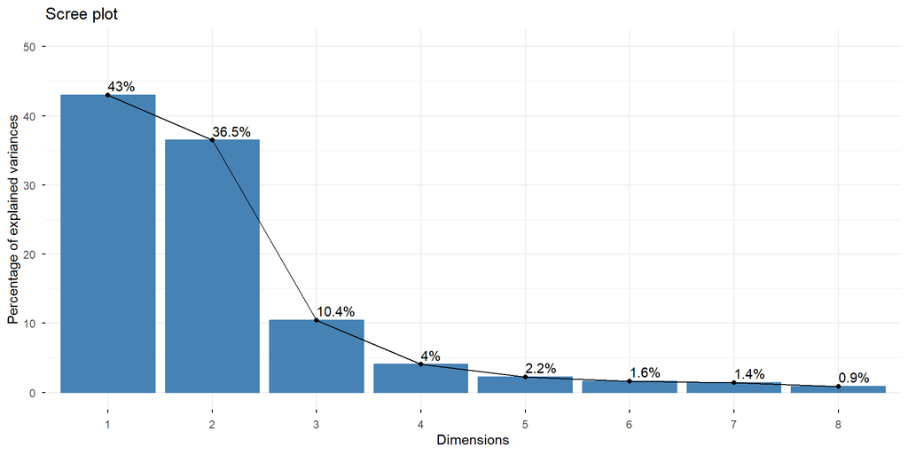

## Contribuciones de las columnas (candidatos)

```r
corrplot(res$col$contrib, is.corr=FALSE, tl.col = "black")
```

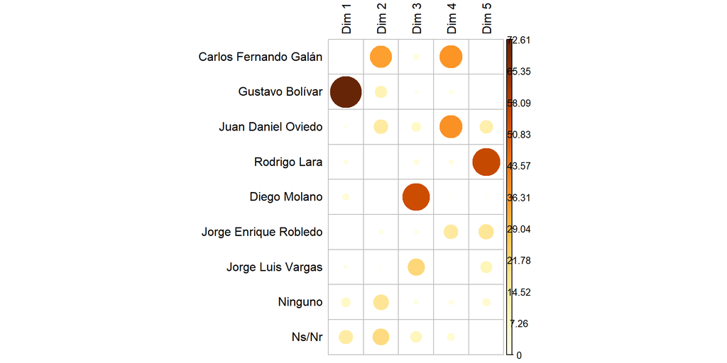

## Contribuciones de las filas (atributos)

```r
corrplot(res$row$contrib, is.corr=FALSE, tl.col = "black")
```

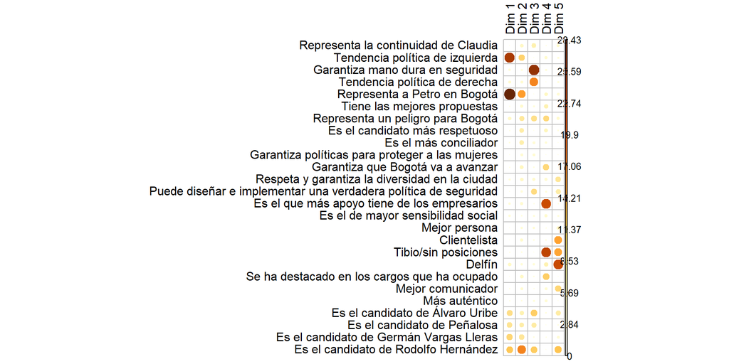

## Análisis de los cosenos para los candidatos

```r
corrplot(res$col$cos2, is.corr=FALSE, tl.col = "black")
```

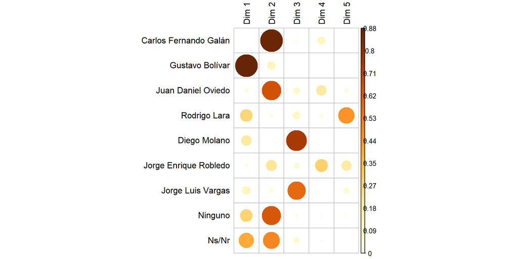

## Análisis de los cosenos para los atributos

```r
corrplot(res$row$cos2, is.corr=FALSE, tl.col = "black")
```

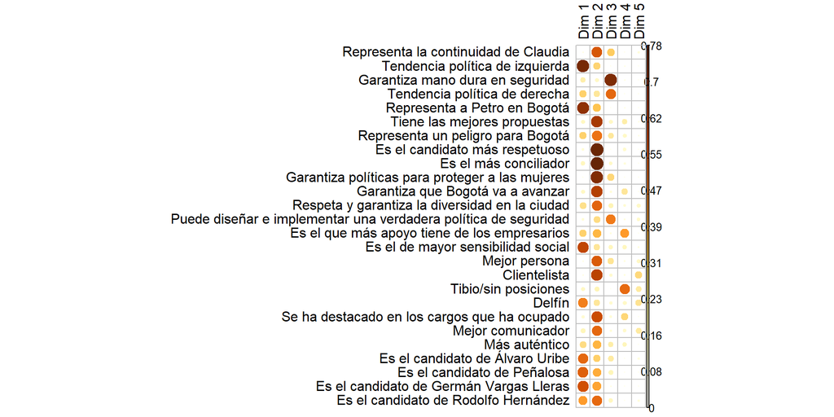

## Perfil de los candidatos (Plano 1-2)

```r
fviz_ca_col(res, repel = TRUE, col.col = "cos2", axes = c(1,2),
            gradient.cols = c("#00AFBB", "#E7B800", "#FC4E07"),
            select.col = list(cos2 = 0.5))
```

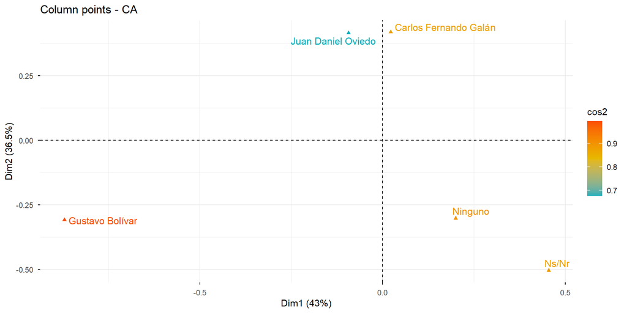

## Posicionamiento de los atributos (Plano 1-2)

```r
fviz_ca_row(res, repel = TRUE, col.row = "cos2", axes = c(1,2),
            gradient.cols = c("lightblue", "blue", "darkblue"),
            select.row = list(cos2 = 0.5))
```

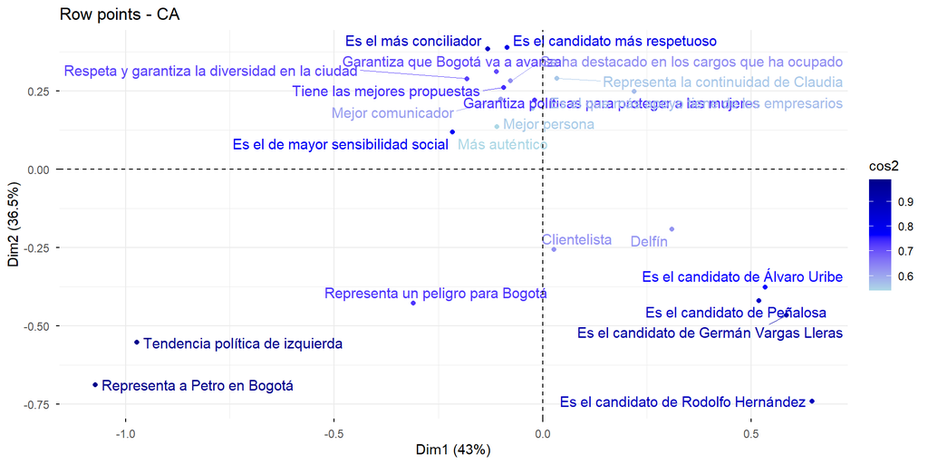

## Biplot de correspondencias

```r
fviz_ca_biplot(res, axes = c(1,2),
               repel = TRUE,
               select.col = list(cos2 = 0.5),
               select.row = list(cos2 = 0.5))
```

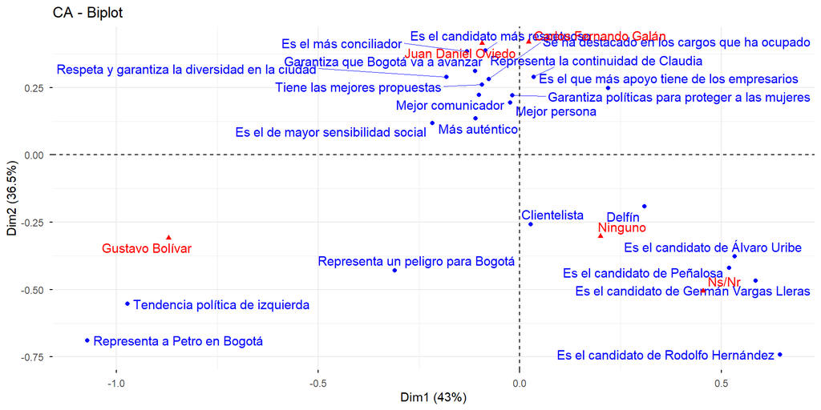

## Análisis complementarios

1. Haga un análisis que le permita encontrar las diferencias y similaridades entre los candidatos Galán, Oviedo, Molano y Vargas.
2. ¿Cuáles son los aspectos que diferencian al candidato Lara frente a los candidatos Galán y Oviedo?.
3. ¿Que modificación debe realizar si su objetivo se centra en encontrar los aspectos que diferencian al candidato Lara frente a los candidatos Molano y Vargas?.

# ESTUDIOS DE CASO: ACM

# CASO 3: Justificaciones para desobedecer la ley — ECC

## Descripción del ejemplo

La ECC incluye una pregunta que indaga si se justifica o no desobedecer la ley en 11 circunstancias (ítems). Para cada ítem el encuestado responde **sí** o **no**.

Las justificaciones son:

| a. Alcanzar sus objetivos | g. No hay castigo |
| --- | --- |
| b. Ayudar a la familia | h. Alguien lo ha hecho y le fue bien |
| c. Luchar contra ley o régimen injusto | i. Es lo acostumbrado |
| d. Por provecho económico | j. Pagar un favor |
| e. Creencia religiosa lo permite | k. Defender propiedades o bienes |
| f. Responder a una ofensa al honor |  |

Se incluyen ciudad y nivel educativo como **variables suplementarias**.

## Carga y preparación de los datos

```r
library(pacman)
p_load(tidyverse, FactoMineR, factoextra, gt, janitor, corrplot)

url <- "https://github.com/jgbabativam/EDM/raw/main/Datos/"
CCLatin <- read.csv2(paste0(url, "Muestra_CC.csv"), sep = ";")

cclp20 <- CCLatin[, c(4, 8, 64:74)]

etiq_si <- c("Si alcanzar objetivos","Si ayudar familia",
             "Si lucha ley reg injusto","Si por provecho económico",
             "Si creencia religiosa","Si resp. ofensa honor",
             "Si no hay castigo","Si alg ha hecho y ha ido bien",
             "Si es lo acostumbrado","Si pagar favor",
             "Si defender prop o bienes")

nombres_p20 <- paste0("P20_", letters[1:11])
for (k in seq_along(nombres_p20)) {
  col <- nombres_p20[k]
  cclp20[[col]][grepl("=1_si", cclp20[[col]])] <- etiq_si[k]
}

# Variables activas: ítems p20a-p20k (sin ciudad ni nivel educativo)
datos_acm <- cclp20[, -(1:2)]
```

## ACM: Valores propios

```r
acm_p20 <- MCA(datos_acm, graph = FALSE)
```

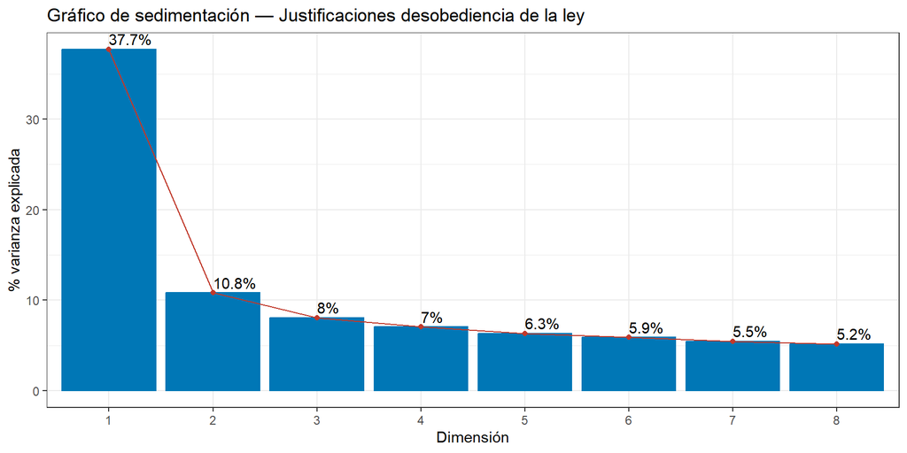

```r
fviz_eig(acm_p20, addlabels = TRUE, ncp = 8,
         barfill = "#0077b6", barcolor = "#0077b6", linecolor = "#C0392B") +
  labs(title = "Gráfico de sedimentación — Justificaciones desobediencia de la ley",
       x = "Dimensión", y = "% varianza explicada") + theme_bw()
```

## Indicadores de modalidades

```r
indp20 <- round(cbind(acm_p20$var$coord[, 1:3],
                      acm_p20$var$contrib[, 1:3],
                      acm_p20$var$cos2[, 1:3]), 2)
indp20 <- indp20[order(indp20[, 4], decreasing = TRUE), ]
colnames(indp20) <- c("Coo F1","Coo F2","Coo F3",
                      "Con F1","Con F2","Con F3",
                      "Cos F1","Cos F2","Cos F3")
head(indp20, 12)
```

```
                              Coo F1 Coo F2 Coo F3 Con F1 Con F2 Con F3 Cos F1
Si no hay castigo               1.58   0.39   0.18   9.49   2.01   0.56   0.47
Si por provecho económico       1.60   0.19   0.64   9.29   0.47   7.01   0.45
Si es lo acostumbrado           1.82   1.09  -0.33   9.29  11.62   1.45   0.44
Si alg ha hecho y ha ido bien   1.86   1.17   0.34   8.37  11.64   1.32   0.39
Si pagar favor                  1.71   1.10  -0.97   8.02  11.58  12.08   0.37
Si creencia religiosa           1.57   0.20   1.21   7.36   0.43  20.43   0.35
Si resp. ofensa honor           1.09  -0.30  -0.08   6.96   1.88   0.16   0.38
Si alcanzar objetivos           1.11  -0.59   0.32   6.86   6.81   2.64   0.37
Si defender prop o bienes       0.73  -0.21  -0.82   4.76   1.39  27.69   0.31
Si lucha ley reg injusto        0.72  -0.63   0.15   4.67  12.52   0.93   0.31
Si ayudar familia               0.62  -0.60  -0.16   4.14  13.29   1.25   0.31
p20b_RDL_AF=2_no               -0.50   0.48   0.13   3.30  10.60   1.00   0.31
                              Cos F2 Cos F3
Si no hay castigo               0.03   0.01
Si por provecho económico       0.01   0.07
Si es lo acostumbrado           0.16   0.01
Si alg ha hecho y ha ido bien   0.15   0.01
Si pagar favor                  0.16   0.12
Si creencia religiosa           0.01   0.21
Si resp. ofensa honor           0.03   0.00
Si alcanzar objetivos           0.11   0.03
Si defender prop o bienes       0.03   0.39
Si lucha ley reg injusto        0.24   0.01
Si ayudar familia               0.28   0.02
p20b_RDL_AF=2_no                0.28   0.02
```

## Plano 1-2: modalidades de respuesta

```r
fviz_mca_var(acm_p20, repel = TRUE, labelsize = 3,
             col.var = "contrib",
             gradient.cols = c("#00AFBB", "#E7B800", "#FC4E07"),
             title = "Plano 1-2: Justificaciones para desobedecer la ley") + theme_bw()
```

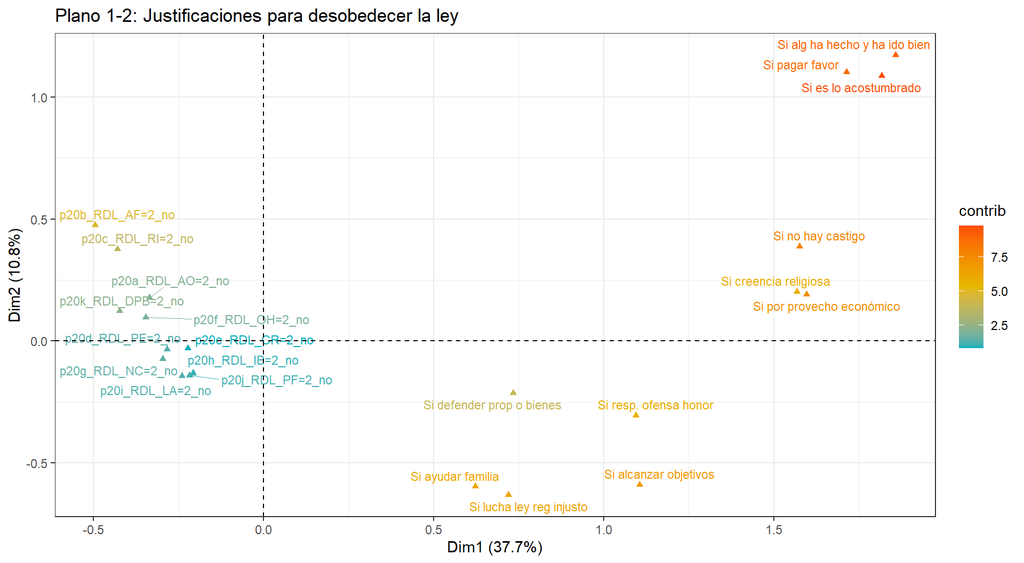

## Interpretación del Factor 1 y Factor 2

- Sobre el **Factor 1**: todas las respuestas “Sí” tienen coordenadas **positivas**; las respuestas “No” tienen coordenadas **negativas**. Es un indicador de la **disposición general a justificar la desobediencia** de la ley.
- Las mayores contribuciones al Factor 1 son de “Sí no hay castigo” y “Sí por provecho económico”: justificaciones de carácter **oportunista/impunidad**.
- El **Factor 2** está tipificado por “Sí ayudar familia” y “Sí lucha contra ley injusta”: justificaciones de tipo **prosocial o cívico**, cualitativamente distintas.
- El Factor 3 distingue “Sí defender propiedades” y “Sí creencia religiosa”: justificaciones más **individuales o filosóficas**.

## Plano 1-2 con variables suplementarias

- Plano
- Código

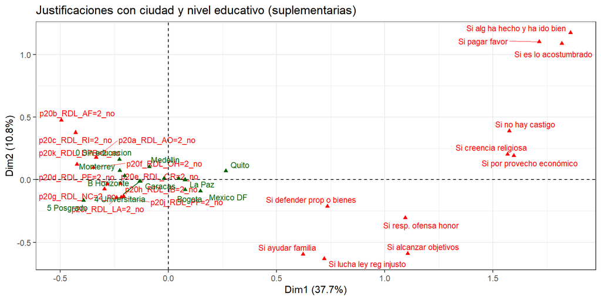

```r
# Construir tabla con ciudad (col 4) y nivel educativo (col 8) como suplementarias
# y P20_a...P20_k (cols 64-74) como variables activas
cclp20_ilus <- CCLatin[, c(4, 8, 64:74)]

for (k in seq_along(nombres_p20)) {
  col <- nombres_p20[k]
  cclp20_ilus[[col]][grepl("=1_si", as.character(cclp20_ilus[[col]]))] <- etiq_si[k]
}

acm_supl <- MCA(cclp20_ilus, quali.sup = c(1, 2), graph = FALSE)

fviz_mca_var(
  acm_supl,
  repel = TRUE,
  labelsize = 3,
  title = "Justificaciones con ciudad y nivel educativo (suplementarias)"
) +
  theme_bw()
```

# CASO 4: Confianza en instituciones — LAPOP Colombia 2021

## Contexto: Barómetro de las Américas

El **Barómetro de las Américas** (LAPOP) es una encuesta científica transnacional que mide actitudes, valores y percepciones ciudadanas en América Latina.

La edición Colombia 2021 incluye **2 993 encuestados** y utiliza un diseño de **muestra dividida**, por lo que distintos módulos se aplican a diferentes subconjuntos de personas.

### Dimensión analizada: **Apoyo al sistema político**

Se utilizan seis preguntas del mismo módulo (*n*= 1 366), medidas en una escala de 1 a 7.

| Var. | Pregunta |
| --- | --- |
| `b2` | Respeto por las instituciones políticas |
| `b3` | Protección de los derechos básicos del ciudadano |
| `b4` | Orgullo de vivir bajo el sistema político |
| `b6` | Apoyo al sistema político |
| `b32` | Confianza en el gobierno local |
| `b47a` | Confianza en las elecciones |

Las respuestas se recodifican en tres categorías:

**Baja (1–3)** · **Media (4)** · **Alta (5–7)**

El género (`q1tb`: Hombre/Mujer) se incorpora como **variable suplementaria**.

## Preparación del conjunto de datos

```r
library(pacman)
p_load(here, tidyverse, FactoMineR, factoextra, corrplot,
       ggrepel, gt, janitor, haven)

url <- "https://github.com/jgbabativam/EDM/raw/main/Datos/"
lapop_raw <- read_dta(paste0(url, "COL_2021_LAPOP.dta"))

recode_trust <- function(x) {
  xn <- suppressWarnings(as.numeric(x))
  dplyr::case_when(
    xn %in% 1:3 ~ "Baja",
    xn == 4     ~ "Media",
    xn %in% 5:7 ~ "Alta",
    TRUE        ~ NA_character_
  )
}

lapop_acm <- lapop_raw |>
  transmute(
    Respeto    = recode_trust(b2),
    Derechos   = recode_trust(b3),
    Orgullo    = recode_trust(b4),
    Apoyo      = recode_trust(b6),
    GobLocal   = recode_trust(b32),
    Elecciones = recode_trust(b47a),
    Genero = dplyr::case_when(
      as.numeric(q1tb) == 1 ~ "Hombre",
      as.numeric(q1tb) == 2 ~ "Mujer",
      TRUE ~ NA_character_
    )
  ) |>
  drop_na() |>
  mutate(across(everything(), factor))
```

## ACM: Valores propios

```r
acm_lapop <- MCA(lapop_acm,
                 quali.sup = which(names(lapop_acm) == "Genero"), graph = FALSE)
```

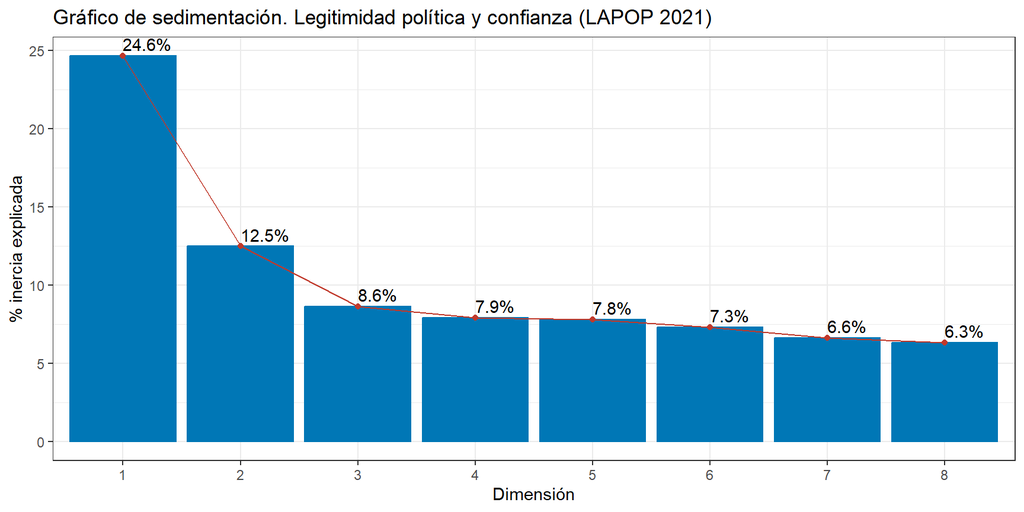

```r
fviz_eig(acm_lapop, addlabels = TRUE, ncp = 8,
         barfill = "#0077b6", barcolor = "#0077b6", linecolor = "#C0392B") +
  labs(title = "Gráfico de sedimentación. Legitimidad política y confianza (LAPOP 2021)", x = "Dimensión", y = "% inercia explicada") + theme_bw()
```

## Plano 1-2: modalidades de confianza

```r
fviz_mca_var(acm_lapop, repel = TRUE, labelsize = 3.5,
             col.var = "contrib",
             gradient.cols = c("#00AFBB", "#E7B800", "#FC4E07"),
             title = "Legitimidad política y confianza institucional — LAPOP Colombia 2021") + theme_bw()
```

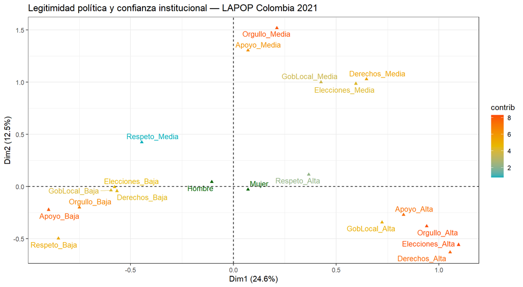

## Plano con género como variable suplementaria

```r
fviz_mca_var(acm_lapop, repel = TRUE, labelsize = 3.5,
             col.var.sup = "#C0392B",
             title = "Legitimidad política con género del encuestado (suplementario). LAPOP 2021") + theme_bw()
```

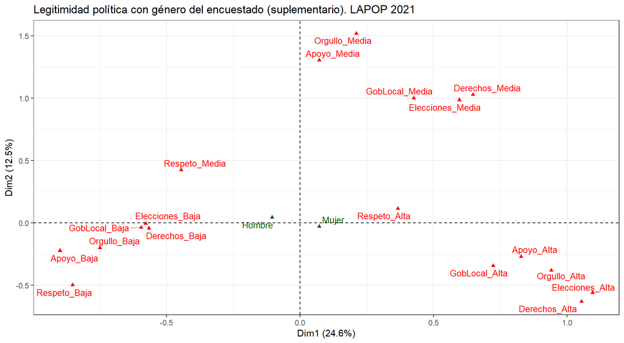

## Plano de individuos

```r
fviz_mca_ind(acm_lapop, geom = "point", alpha.ind = 0.3,
             col.ind = "cos2",
             gradient.cols = c("#00AFBB", "#E7B800", "#FC4E07"),
             title = "Encuestados: Legitimidad política LAPOP Colombia 2021") + theme_bw()
```

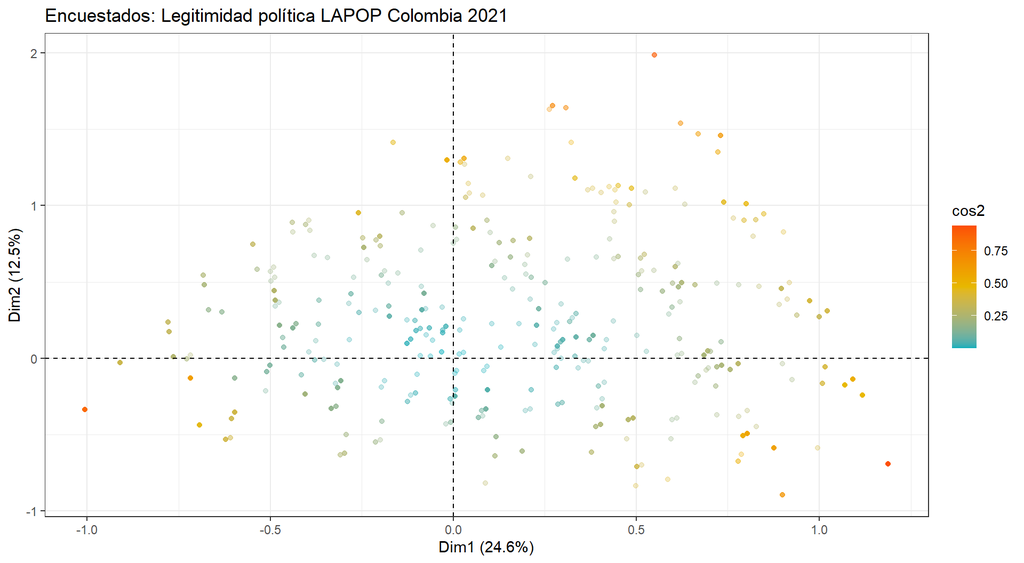

## Interpretación

- El **Factor 1** es un eje de **legitimidad política general**: en un extremo, todas las modalidades “Alta” (quienes valoran las instituciones); en el otro, todas las modalidades “Baja” (quienes las rechazan). Muestra en su **zona de valores positivos** a quienes consideran que hay un alto grado de respeto por las instituciones, apoyo y orgullo por el sistema político, confianza en las elecciones y protección de los derechos, lo que indica alto grado de **optimismo respecto de la Estabilidad y el Funcionamiento de las Instituciones Democráticas (EFID)**, mientras que en la **zona de valores negativos** del mismo factor se encuentran sus contrapartes indicando **pesimismo en cuanto a la EFID**.
- El **Factor 2** muestra un **optimismo moderado (medio)** respecto a la **EFID** exeptuando el respeto por las instituciones el cual está posiciomado cerca de las percepciones bajas o pesimistas.
- La variable suplementaria **Género**, muestra que en Colombia, las mujeres tienden a ser **levemente más optimistas** en su percepción sobre la **EFID** que los hombres.

## Examen 2

Vea las condiciones del examen 2 en Bloque Neón y en GitHub

- [Examen 2](https://github.com/jgbabativam/AnaDatos/tree/main/Talleres)

Lea atentamente las instrucciones del mismo, tenga en cuenta que los ejercicios propuestos no son para entregar en un formato tipo taller, sino que le deben servir como recurso para generar el documento solicitado.

## Exposición final

Lea atentamente las siguientes instrucciones y observe el siguiente vídeo (asegúrese de dar clic en la ventana externa):

- [Rúbrica de evaluación](https://github.com/jgbabativam/AnaDatos/tree/main/Talleres)
- [Video tutorial](https://youtu.be/W0TdujuLJSo)

# GRACIAS!

# Referencias

- Husson, F., Lê, S., & Pagès, J. (2017). Exploratory multivariate analysis by example using R. CRC press.
- Hair, J. F., Black, W. C., Babin, B. J., Anderson, R. E., & Tatham, R. L. (2006). Multivariate data analysis 6th Edition. https://doi.org/10.1201/9780367409913
- Aldás Manzano, J., & Uriel Jiménez, E. (2017). Análisis multivariante aplicado con R. Ediciones Paraninfo, SA.